# Task 5: Exploratory Data Analysis (EDA)

**Dataset:** Retail Store Sales  
**Tools:** Python (Pandas, Numpy, Matplotlib, Seaborn)  
**Objective:** Extract insights using visual and statistical exploration find patterns, trends, and anomalies in the data.

EDA is always the first step after cleaning. Before building any model or dashboard, we need to *understand* our data what it looks like, how values are distributed, and which columns are related to each other.

## PART 1: **Data Cleaning**

## Import libraries and load the data

We need two libraries:

- **pandas** — to load and work with our data as a table (called a DataFrame)
- **numpy** — for numeric operations, mainly used when handling missing values

We then load our CSV file into a DataFrame called `df` (short for "dataframe").

```python
import pandas as pd
import numpy as np
```

```python
df = pd.read_csv(r'C:\Users\Admin\Downloads\archive\retail_store_sales.csv')
```

```python
# Let's look at the first 5 rows to get a feel for the data
df.head()
```

|  | Transaction ID | Customer ID | Category | Item | Price Per Unit | Quantity | Total Spent | Payment Method | Location | Transaction Date | Discount Applied |
| --- | --- | --- | --- | --- | --- | --- | --- | --- | --- | --- | --- |
| 0 | TXN_6867343 | CUST_09 | Patisserie | Item_10_PAT | 18.5 | 10.0 | 185.0 | Digital Wallet | Online | 2024-04-08 | True |
| 1 | TXN_3731986 | CUST_22 | Milk Products | Item_17_MILK | 29.0 | 9.0 | 261.0 | Digital Wallet | Online | 2023-07-23 | True |
| 2 | TXN_9303719 | CUST_02 | Butchers | Item_12_BUT | 21.5 | 2.0 | 43.0 | Credit Card | Online | 2022-10-05 | False |
| 3 | TXN_9458126 | CUST_06 | Beverages | Item_16_BEV | 27.5 | 9.0 | 247.5 | Credit Card | Online | 2022-05-07 | NaN |
| 4 | TXN_4575373 | CUST_05 | Food | Item_6_FOOD | 12.5 | 7.0 | 87.5 | Digital Wallet | Online | 2022-10-02 | False |

```python
# How many rows and columns do we have?
print("Shape of dataset (rows, columns):", df.shape)
```

```
Shape of dataset (rows, columns): (12575, 11)
```

## Step 1: Identify and handle missing values

**Why this matters:** Missing values (also called "nulls" or "NaN") can break calculations, cause wrong conclusions, or crash machine learning models. Before fixing anything, we first need to *see* where the gaps are.

We use `.isnull().sum()` this checks every cell in every column and counts how many are empty.

```python
# Check for missing values in each column
df.isnull().sum()
```

```
Transaction ID         0
Customer ID            0
Category               0
Item                1213
Price Per Unit       609
Quantity             604
Total Spent          604
Payment Method         0
Location               0
Transaction Date       0
Discount Applied    4199
dtype: int64
```

**What we found:** Missing values exist in `Item`, `Price Per Unit`, `Quantity`, `Total Spent`, and `Discount Applied`.

**How we'll fix each one:**

1. **Item** — we don't have enough information to guess what the actual item was, so we'll label it `'Unknown'`. This way we keep the row instead of losing data, but we're honest that the value wasn't recorded.
2. **Discount Applied** — about a third of rows don't say whether a discount was used. Since we have no way to know for sure, we'll **assume `False`** (no discount) for missing entries. This is a reasonable default we document this assumption clearly so anyone reading our work understands the choice.
3. **Price Per Unit, Quantity, Total Spent** — these three numbers are mathematically connected: `Total Spent = Price Per Unit × Quantity`

   Instead of guessing these values randomly, we can use this formula to recover missing ones whenever we know the other two. This is much more accurate than filling with an average.

```python
# Fix 1: Item — fill missing item codes with 'Unknown'
df['Item'] = df['Item'].fillna('Unknown')
```

```python
# Fix 2: Discount Applied — fill missing values with False
df['Discount Applied'] = df['Discount Applied'].fillna(False)
```

```python
# Fix 3: Recover Price / Quantity / Total Spent using their relationship
# Total Spent = Price Per Unit x Quantity
```

```python
# (a) If Total Spent is missing but we know Price and Quantity, calculate it
mask = df['Total Spent'].isnull()
```

```python
# (a) If Total Spent is missing but we know Price and Quantity, calculate it
mask = df['Total Spent'].isnull() & df['Price Per Unit'].notnull() & df['Quantity'].notnull()
df.loc[mask, 'Total Spent'] = df.loc[mask, 'Price Per Unit'] * df.loc[mask, 'Quantity']
```

```python
# (c) If Quantity is missing but we know Total Spent and Price Per Unit, calculate it
mask = df['Quantity'].isnull() & df['Total Spent'].notnull() & df['Price Per Unit'].notnull()
df.loc[mask, 'Quantity'] = df.loc[mask, 'Total Spent'] / df.loc[mask, 'Price Per Unit']
```

```python
# Check how many nulls are left in these 3 columns
df[['Price Per Unit', 'Quantity', 'Total Spent']].isnull().sum()
```

```
Price Per Unit    609
Quantity          604
Total Spent       604
dtype: int64
```

```python
# Fill any remaining nulls (where all 3 were missing together) with the column mean
for col in ['Price Per Unit', 'Quantity', 'Total Spent']:
    df[col] = df[col].fillna(df[col].mean())
```

```python
# Final check — this should show 0 for every column now
df.isnull().sum()
```

```
Transaction ID      0
Customer ID         0
Category            0
Item                0
Price Per Unit      0
Quantity            0
Total Spent         0
Payment Method      0
Location            0
Transaction Date    0
Discount Applied    0
dtype: int64
```

## Step 2: Remove duplicate rows

**Why this matters:** Duplicate rows can happen due to system errors, double data entry, or merging files incorrectly. They artificially inflate counts and totals, skewing any analysis we do later.

`.duplicated()` checks every row against every other row and flags exact copies. `.drop_duplicates()` removes them.

```python
# How many exact duplicate rows do we have?
print("Duplicate rows found:", df.duplicated().sum())
```

```
Duplicate rows found: 0
```

```python
# Remove them (if any)
df = df.drop_duplicates()

print("Shape after removing duplicates:", df.shape)
```

```
Shape after removing duplicates: (12575, 11)
```

## Step 3: Standardize text values

**Why this matters:** The same value can be written in different ways `"male"`, `"Male"`, `"MALE"` and a computer treats these as three *different* categories unless we standardize them. This causes incorrect grouping and counting.

We'll check the text columns (`Category`, `Payment Method`, `Location`) and make their formatting consistent removing extra spaces and using Title Case (first letter capitalized).

```python
# Look at the unique values before standardizing
print("Category:", df['Category'].unique())
print("Payment Method:", df['Payment Method'].unique())
print("Location:", df['Location'].unique())
```

```
Category: ['Patisserie' 'Milk Products' 'Butchers' 'Beverages' 'Food' 'Furniture'
 'Electric household essentials' 'Computers and electric accessories']
Payment Method: ['Digital Wallet' 'Credit Card' 'Cash']
Location: ['Online' 'In-store']
```

```python
# Standardize: remove extra spaces, make Title Case
for col in ['Category', 'Payment Method', 'Location']:
    df[col] = df[col].str.strip().str.title()

# Confirm the cleanup
print("Category:", df['Category'].unique())
print("Payment Method:", df['Payment Method'].unique())
print("Location:", df['Location'].unique())
```

```
Category: ['Patisserie' 'Milk Products' 'Butchers' 'Beverages' 'Food' 'Furniture'
 'Electric Household Essentials' 'Computers And Electric Accessories']
Payment Method: ['Digital Wallet' 'Credit Card' 'Cash']
Location: ['Online' 'In-Store']
```

## Step 4: Convert date formats to a consistent type

**Why this matters:** Dates stored as plain text (strings) can't be sorted, filtered by range, or used in time-based calculations properly. We need to convert the column into an actual datetime type, then display it in one consistent format: **dd-mm-yyyy**.

```python
# Check current format
print(df['Transaction Date'].head())
print(df['Transaction Date'].dtype)
```

```
0    2024-04-08
1    2023-07-23
2    2022-10-05
3    2022-05-07
4    2022-10-02
Name: Transaction Date, dtype: object
object
```

```python
# Step 1: Convert text to a real datetime object
df['Transaction Date'] = pd.to_datetime(df['Transaction Date'])
```

```python
# Step 2: Format it consistently as dd-mm-yyyy
df['Transaction Date'] = df['Transaction Date'].dt.strftime('%d-%m-%Y')

print(df['Transaction Date'].head())
```

```
0    08-04-2024
1    23-07-2023
2    05-10-2022
3    07-05-2022
4    02-10-2022
Name: Transaction Date, dtype: object
```

Transaction Date shows as object here that's fine since you formatted it as a dd-mm-yyyy string for display in Step 4, which converts it from datetime back to text. (Just know that if you need to filter or sort by date later, you'd reconvert with pd.to_datetime() first.)

## Step 5: Rename column headers to be clean and uniform

```python
print("Before:", list(df.columns))

df.columns = df.columns.str.strip().str.lower().str.replace(' ', '_')

print("After:", list(df.columns))
```

```
Before: ['Transaction ID', 'Customer ID', 'Category', 'Item', 'Price Per Unit', 'Quantity', 'Total Spent', 'Payment Method', 'Location', 'Transaction Date', 'Discount Applied']
After: ['transaction_id', 'customer_id', 'category', 'item', 'price_per_unit', 'quantity', 'total_spent', 'payment_method', 'location', 'transaction_date', 'discount_applied']
```

## Step 6: Check and fix data types

**Why this matters:** A column might *look* like numbers but actually be stored as text (called an "object" dtype in pandas). This breaks any math we try to do on it. We check each column's dtype and fix any mismatches e.g., quantity should be a whole number (int), price should be a decimal (float), and discount_applied should be a True/False value (boolean).

```python
# Check current data types
df.dtypes
```

```
transaction_id       object
customer_id          object
category             object
item                 object
price_per_unit      float64
quantity            float64
total_spent         float64
payment_method       object
location             object
transaction_date     object
discount_applied       bool
dtype: object
```

```python
# Fix data types
df['quantity'] = df['quantity'].astype(int)
df['price_per_unit'] = df['price_per_unit'].astype(float).round(2)
df['total_spent'] = df['total_spent'].astype(float).round(2)
df['discount_applied'] = df['discount_applied'].astype(bool)

# Confirm the fix
df.dtypes
```

```
transaction_id       object
customer_id          object
category             object
item                 object
price_per_unit      float64
quantity              int32
total_spent         float64
payment_method       object
location             object
transaction_date     object
discount_applied       bool
dtype: object
```

**Why this matters:** Outliers are values that are unusually high or low compared to the rest of the data sometimes they're genuine (a big bulk order), and sometimes they're data entry errors. We use the **IQR method** (Interquartile Range) to flag them, then decide whether to keep or remove them.

## Final Step: Save the cleaned dataset

Now that every issue has been fixed, we save our clean DataFrame to a new CSV file this is our final deliverable.

```python
df.to_csv('cleaned_retail_store_sales.csv', index=False)
print("Cleaned dataset saved successfully!")
print("Final shape:", df.shape)
df.head()
```

```
Cleaned dataset saved successfully!
Final shape: (12575, 11)
```

|  | transaction_id | customer_id | category | item | price_per_unit | quantity | total_spent | payment_method | location | transaction_date | discount_applied |
| --- | --- | --- | --- | --- | --- | --- | --- | --- | --- | --- | --- |
| 0 | TXN_6867343 | CUST_09 | Patisserie | Item_10_PAT | 18.5 | 10 | 185.0 | Digital Wallet | Online | 08-04-2024 | True |
| 1 | TXN_3731986 | CUST_22 | Milk Products | Item_17_MILK | 29.0 | 9 | 261.0 | Digital Wallet | Online | 23-07-2023 | True |
| 2 | TXN_9303719 | CUST_02 | Butchers | Item_12_BUT | 21.5 | 2 | 43.0 | Credit Card | Online | 05-10-2022 | False |
| 3 | TXN_9458126 | CUST_06 | Beverages | Item_16_BEV | 27.5 | 9 | 247.5 | Credit Card | Online | 07-05-2022 | False |
| 4 | TXN_4575373 | CUST_05 | Food | Item_6_FOOD | 12.5 | 7 | 87.5 | Digital Wallet | Online | 02-10-2022 | False |

## Conclusion

**What I learned:** Data cleaning isn't just about removing problems it's about making informed decisions at each step and being able to explain *why* you made them. Using relationships between columns (like Price × Quantity = Total) to recover missing data is far more reliable than guessing with averages, and should always be checked first before falling back to simpler methods.

The final cleaned dataset (`cleaned_retail_store_sales.csv`) is now ready for further analysis, visualization, or modelling.

## PART 2: EXPLORATORY DATA ANALYSIS (EDA)

We need four libraries for EDA:

- **pandas** — load and summarize data
- **matplotlib** — base plotting library
- **seaborn** — built on top of matplotlib, makes statistical charts easier and prettier
- **warnings** — we'll suppress minor warnings so output stays clean

```python
import pandas as pd
import matplotlib.pyplot as plt
import seaborn as sns
import warnings
warnings.filterwarnings('ignore')
```

```python
# Set a consistent style for all charts
sns.set_theme(style='whitegrid')
plt.rcParams['figure.figsize'] = (10, 5)
```

```python
# Load the cleaned dataset
df = pd.read_csv('cleaned_retail_store_sales.csv')

print("Dataset loaded successfully!")
print("Shape:", df.shape)
df.head()
```

```
Dataset loaded successfully!
Shape: (12575, 11)
```

|  | transaction_id | customer_id | category | item | price_per_unit | quantity | total_spent | payment_method | location | transaction_date | discount_applied |
| --- | --- | --- | --- | --- | --- | --- | --- | --- | --- | --- | --- |
| 0 | TXN_6867343 | CUST_09 | Patisserie | Item_10_PAT | 18.5 | 10 | 185.0 | Digital Wallet | Online | 08-04-2024 | True |
| 1 | TXN_3731986 | CUST_22 | Milk Products | Item_17_MILK | 29.0 | 9 | 261.0 | Digital Wallet | Online | 23-07-2023 | True |
| 2 | TXN_9303719 | CUST_02 | Butchers | Item_12_BUT | 21.5 | 2 | 43.0 | Credit Card | Online | 05-10-2022 | False |
| 3 | TXN_9458126 | CUST_06 | Beverages | Item_16_BEV | 27.5 | 9 | 247.5 | Credit Card | Online | 07-05-2022 | False |
| 4 | TXN_4575373 | CUST_05 | Food | Item_6_FOOD | 12.5 | 7 | 87.5 | Digital Wallet | Online | 02-10-2022 | False |

## Step 1: Statistical Summary using `.describe()`, `.info()`, `.value_counts()`

**Why this matters:** Before plotting anything, we look at the numbers how many rows, what data types, what the average values are, what the min and max are. This gives us a "first impression" of the dataset and tells us where to dig deeper.

```python
# .info() — shows column names, data types, and non-null counts
df.info()
```

```
<class 'pandas.core.frame.DataFrame'>
RangeIndex: 12575 entries, 0 to 12574
Data columns (total 11 columns):
 #   Column            Non-Null Count  Dtype
---  ------            --------------  -----
 0   transaction_id    12575 non-null  object
 1   customer_id       12575 non-null  object
 2   category          12575 non-null  object
 3   item              12575 non-null  object
 4   price_per_unit    12575 non-null  float64
 5   quantity          12575 non-null  int64
 6   total_spent       12575 non-null  float64
 7   payment_method    12575 non-null  object
 8   location          12575 non-null  object
 9   transaction_date  12575 non-null  object
 10  discount_applied  12575 non-null  bool
dtypes: bool(1), float64(2), int64(1), object(7)
memory usage: 994.8+ KB
```

```python
# .describe() — shows count, mean, min, max, and quartiles for numeric columns
df.describe().round(2)
```

|  | price_per_unit | quantity | total_spent |
| --- | --- | --- | --- |
| count | 12575.00 | 12575.00 | 12575.00 |
| mean | 23.37 | 5.51 | 129.65 |
| std | 10.48 | 2.79 | 92.45 |
| min | 5.00 | 1.00 | 5.00 |
| 25% | 14.00 | 3.00 | 55.00 |
| 50% | 23.37 | 5.00 | 112.50 |
| 75% | 32.00 | 8.00 | 184.00 |
| max | 41.00 | 10.00 | 410.00 |

```python
print("=== Category ===")
print(df['category'].value_counts())
print()
print("=== Payment Method ===")
print(df['payment_method'].value_counts())
print()
print("=== Location ===")
print(df['location'].value_counts())
print()
print("=== Discount Applied ===")
print(df['discount_applied'].value_counts())
```

```
=== Category ===
category
Furniture                             1591
Electric Household Essentials         1591
Food                                  1588
Milk Products                         1584
Butchers                              1568
Beverages                             1567
Computers And Electric Accessories    1558
Patisserie                            1528
Name: count, dtype: int64

=== Payment Method ===
payment_method
Cash              4310
Digital Wallet    4144
Credit Card       4121
Name: count, dtype: int64

=== Location ===
location
Online      6354
In-Store    6221
Name: count, dtype: int64

=== Discount Applied ===
discount_applied
False    8356
True     4219
Name: count, dtype: int64
```

**Observations from Step 1:**

## Step 2: Univariate Analysis — Histograms

**What is univariate analysis?** It means looking at *one column at a time* to understand its distribution — is it spread out, bunched together, skewed to one side?

**Histogram** — divides values into "bins" (ranges) and shows how many rows fall into each bin. A tall bar means many rows have that value.

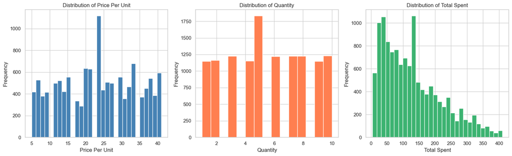

```python
fig, axes = plt.subplots(1, 3, figsize=(16, 5))

# Price Per Unit
axes[0].hist(df['price_per_unit'], bins=30, color='steelblue', edgecolor='white')
axes[0].set_title('Distribution of Price Per Unit')
axes[0].set_xlabel('Price Per Unit')
axes[0].set_ylabel('Frequency')

# Quantity
axes[1].hist(df['quantity'], bins=15, color='coral', edgecolor='white')
axes[1].set_title('Distribution of Quantity')
axes[1].set_xlabel('Quantity')
axes[1].set_ylabel('Frequency')

# Total Spent
axes[2].hist(df['total_spent'], bins=30, color='mediumseagreen', edgecolor='white')
axes[2].set_title('Distribution of Total Spent')
axes[2].set_xlabel('Total Spent')
axes[2].set_ylabel('Frequency')

plt.tight_layout()
plt.savefig('hist_distributions.png', dpi=150, bbox_inches='tight')
plt.show()
```

**Observations:**

## Step 3: Univariate Analysis — Boxplots

**Boxplot** — shows the median (middle line), the interquartile range (box = middle 50% of data), and outliers (individual dots beyond the whiskers).

It answers: *How spread out is this column? Are there extreme values?*

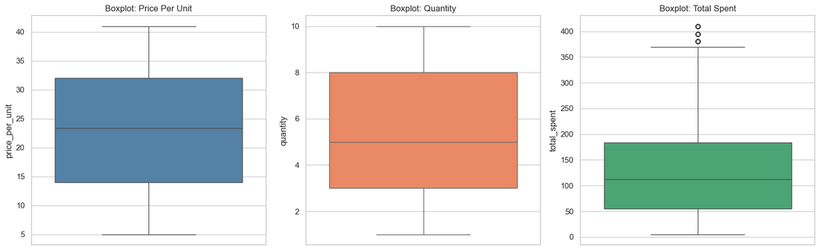

```python
fig, axes = plt.subplots(1, 3, figsize=(16, 5))

sns.boxplot(y=df['price_per_unit'], ax=axes[0], color='steelblue')
axes[0].set_title('Boxplot: Price Per Unit')

sns.boxplot(y=df['quantity'], ax=axes[1], color='coral')
axes[1].set_title('Boxplot: Quantity')

sns.boxplot(y=df['total_spent'], ax=axes[2], color='mediumseagreen')
axes[2].set_title('Boxplot: Total Spent')

plt.tight_layout()
plt.savefig('boxplots.png', dpi=150, bbox_inches='tight')
plt.show()
```

**Observations:**

## Step 4: Bivariate Analysis — Category vs Total Spent

**What is bivariate analysis?** Looking at *two columns together* to understand their relationship.

Here we want to know: *Which product category generates the most revenue?*

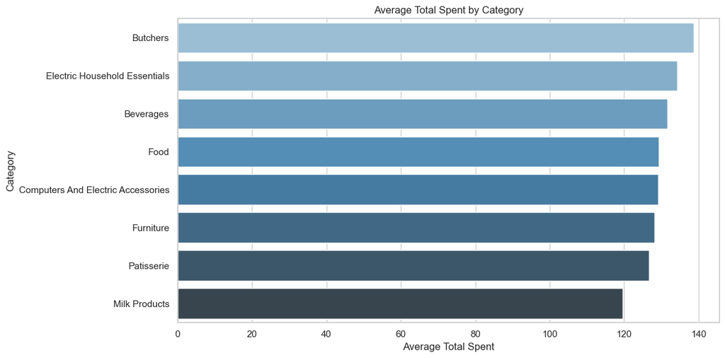

```python
# Average total spent per category
category_avg = df.groupby('category')['total_spent'].mean().sort_values(ascending=False).reset_index()

plt.figure(figsize=(12, 6))
sns.barplot(data=category_avg, x='total_spent', y='category', palette='Blues_d')
plt.title('Average Total Spent by Category')
plt.xlabel('Average Total Spent')
plt.ylabel('Category')
plt.tight_layout()
plt.savefig('category_avg_spend.png', dpi=150, bbox_inches='tight')
plt.show()
```

**Observations:**

## Step 5: Bivariate Analysis — Scatterplot

**Scatterplot** — plots two numeric columns against each other. Each dot represents one row. If dots form a pattern (going up or down together), there is a relationship between the two columns.

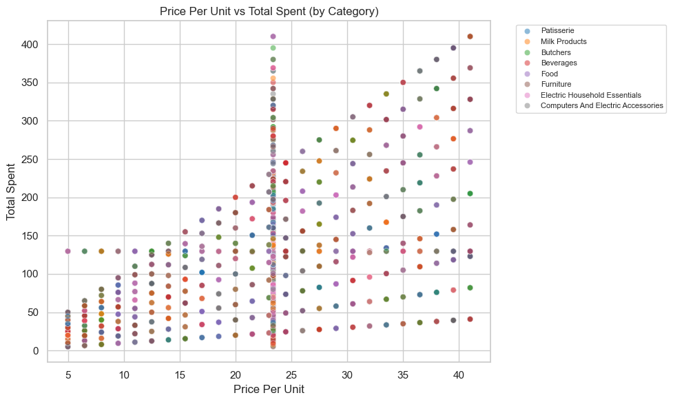

```python
plt.figure(figsize=(10, 6))
sns.scatterplot(data=df, x='price_per_unit', y='total_spent',
                hue='category', alpha=0.5, palette='tab10')
plt.title('Price Per Unit vs Total Spent (by Category)')
plt.xlabel('Price Per Unit')
plt.ylabel('Total Spent')
plt.legend(bbox_to_anchor=(1.05, 1), loc='upper left', fontsize=8)
plt.tight_layout()
plt.savefig('scatter_price_vs_total.png', dpi=150, bbox_inches='tight')
plt.show()
```

**Observations:**

## Step 6: Bivariate Analysis — Payment Method and Location

Let's explore how customers prefer to pay and where they shop most.

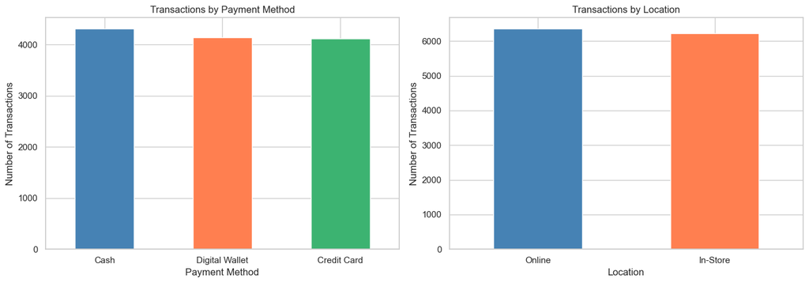

```python
fig, axes = plt.subplots(1, 2, figsize=(14, 5))

# Payment Method distribution
df['payment_method'].value_counts().plot(kind='bar', ax=axes[0],
    color=['steelblue','coral','mediumseagreen'], edgecolor='white', rot=0)
axes[0].set_title('Transactions by Payment Method')
axes[0].set_xlabel('Payment Method')
axes[0].set_ylabel('Number of Transactions')

# Location distribution
df['location'].value_counts().plot(kind='bar', ax=axes[1],
    color=['steelblue','coral'], edgecolor='white', rot=0)
axes[1].set_title('Transactions by Location')
axes[1].set_xlabel('Location')
axes[1].set_ylabel('Number of Transactions')

plt.tight_layout()
plt.savefig('payment_location.png', dpi=150, bbox_inches='tight')
plt.show()
```

**Observations:**

- All three payment methods (Digital Wallet, Credit Card, Cash) are used roughly equally no single method dominates, suggesting a diverse customer base.
- Online and In-store transactions are nearly equal in count this retailer has a balanced omnichannel presence.
- No payment method or location has a significantly higher share, meaning the business doesn't depend on any single channel.

## Step 7: Discount Analysis

Let's see whether applying a discount actually leads to higher spending per transaction.

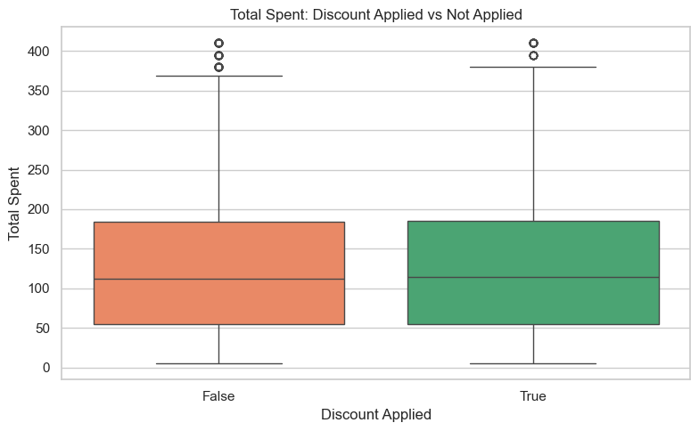

```
discount_applied
False    129.25
True     130.45
Name: total_spent, dtype: float64
```

```python
plt.figure(figsize=(8, 5))
sns.boxplot(data=df, x='discount_applied', y='total_spent',
            palette={'True': 'mediumseagreen', 'False': 'coral'})
plt.title('Total Spent: Discount Applied vs Not Applied')
plt.xlabel('Discount Applied')
plt.ylabel('Total Spent')
plt.tight_layout()
plt.savefig('discount_vs_spend.png', dpi=150, bbox_inches='tight')
plt.show()

# Average total spent with vs without discount
print(df.groupby('discount_applied')['total_spent'].mean().round(2))
```

**Observations:**

- The median total spent is similar whether or not a discount was applied.
- This suggests discounts in this dataset don't dramatically change individual transaction values they may attract more transactions rather than increasing value per transaction.
- A retailer could investigate further: are discounts driving volume (more transactions) rather than value (higher spend per transaction)?

## Step 8: Multivariate Analysis — Correlation Heatmap

**What is multivariate analysis?** Looking at *three or more columns together*.

**Heatmap** — shows the correlation between every pair of numeric columns.

- Values close to **+1** = strong positive relationship (both go up together)
- Values close to **-1** = strong negative relationship (one goes up, other goes down)
- Values close to **0** = no relationship

**Correlation does not mean causation** it just shows that two numbers move together.

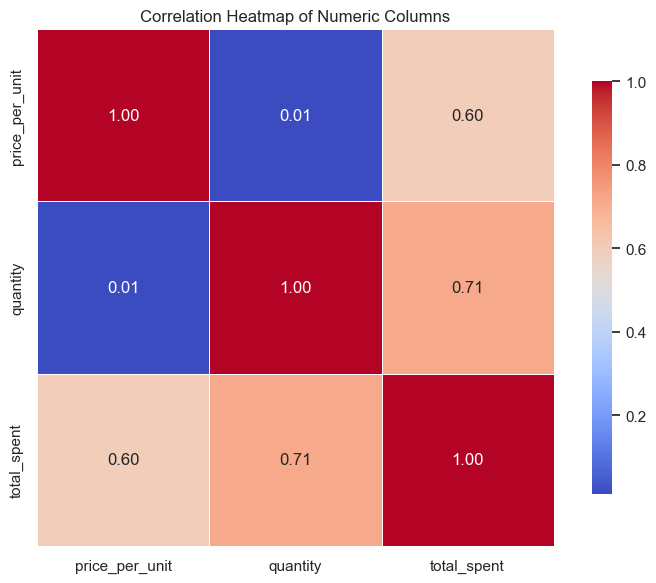

```python
# Select numeric columns only
numeric_cols = df[['price_per_unit', 'quantity', 'total_spent']]

plt.figure(figsize=(8, 6))
sns.heatmap(numeric_cols.corr(), annot=True, fmt='.2f',
            cmap='coolwarm', linewidths=0.5, square=True,
            cbar_kws={'shrink': 0.8})
plt.title('Correlation Heatmap of Numeric Columns')
plt.tight_layout()
plt.savefig('heatmap_correlation.png', dpi=150, bbox_inches='tight')
plt.show()
```

**Observations:**

## Step 9: Multivariate Analysis — Pairplot

**Pairplot** — creates a grid of scatterplots for every combination of numeric columns, plus histograms on the diagonal showing each column's own distribution.

Think of it as a "see everything at once" chart. It takes a moment to render since it draws many plots simultaneously.

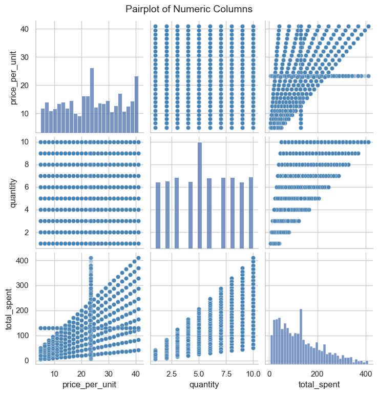

```python
sns.pairplot(df[['price_per_unit', 'quantity', 'total_spent']],
             diag_kind='hist', plot_kws={'alpha': 0.4, 'color': 'steelblue'})
plt.suptitle('Pairplot of Numeric Columns', y=1.02, fontsize=14)
plt.savefig('pairplot.png', dpi=150, bbox_inches='tight')
plt.show()
```

**Observations:**

## Step 10: Category Sales Distribution — Count and Revenue

Let's now look at both *number of transactions* and *total revenue* per category side by side.

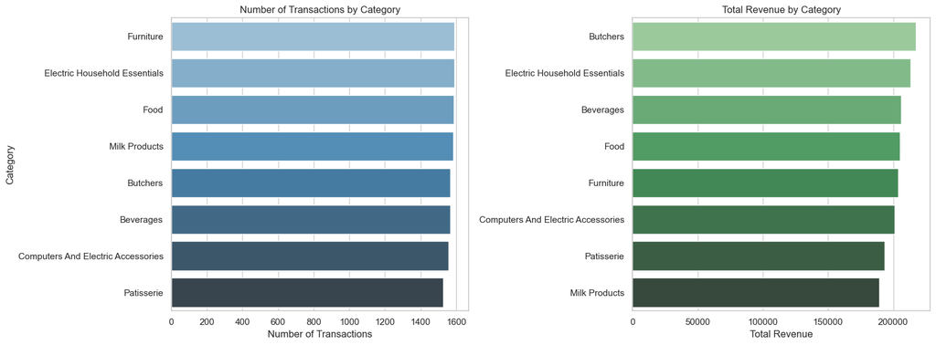

```python
fig, axes = plt.subplots(1, 2, figsize=(16, 6))

# Number of transactions per category
cat_count = df['category'].value_counts()
sns.barplot(x=cat_count.values, y=cat_count.index, ax=axes[0], palette='Blues_d')
axes[0].set_title('Number of Transactions by Category')
axes[0].set_xlabel('Number of Transactions')
axes[0].set_ylabel('Category')

# Total revenue per category
cat_revenue = df.groupby('category')['total_spent'].sum().sort_values(ascending=False)
sns.barplot(x=cat_revenue.values, y=cat_revenue.index, ax=axes[1], palette='Greens_d')
axes[1].set_title('Total Revenue by Category')
axes[1].set_xlabel('Total Revenue')
axes[1].set_ylabel('')

plt.tight_layout()
plt.savefig('category_count_revenue.png', dpi=150, bbox_inches='tight')
plt.show()
```

**Observations:**

## Summary of Findings

After performing Exploratory Data Analysis on the cleaned retail sales dataset (12,575 transactions), here are the key insights:

[output not shown]

## Conclusion

These insights would directly guide any further analysis, dashboard design, or machine learning work on this dataset.